```r
library(concatstring)
```

## Introduction

The `concatstring` package is a lightweight R package designed to combine two character vectors elementwise using `paste()`, returning the result as a structured object of class `concat_result`.

### Why use this package?

This package provides:

- A custom S3 class (`concat_result`) to wrap the result
- A `print()` method for clean console output
- A `summary()` method for descriptive summaries
- A `plot()` method for visualising string lengths

It’s intended for teaching, lightweight text analysis, or wrapping basic string operations in a reusable and extensible format.

## Basic usage

You can combine two strings using:

```r
concat_strings("Hello", "World")
```

```
#> Concatenated result:
#> [1] "Hello World"
```

This returns an object of class `concat_result`, which contains:

- The original inputs `x` and `y`
- The concatenated result `result`
- The class `"concat_result"`

## Vector input

The function is vectorised, meaning it works elementwise over character vectors of the same length:

```r
concat_strings(c("Fast", "Strong"), c("Car", "Wind"))
```

```
#> Concatenated result:
#> [1] "Fast Car"    "Strong Wind"
```

## Output structure

You can inspect the structure of a `concat_result` object using `str()`:

```r
res <- concat_strings("Hello", "World")
str(res)
```

```
#> List of 3
#>  $ x     : chr "Hello"
#>  $ y     : chr "World"
#>  $ result: chr "Hello World"
#>  - attr(*, "class")= chr "concat_result"
```

## S3 methods

The package includes print, summary, and plot methods specific to `concat_result`.

### Print

```r
print(res)
```

```
#> Concatenated result:
#> [1] "Hello World"
```

### Summary

```r
summary(res)
```

```
#> Summary of concatenated result:
#> Number of input elements: 1
#> First few results:
#> [1] "Hello World"
```

This tells you how many elements were concatenated and shows the first few results.

### Plot

When the result contains multiple elements, the `plot()` method creates a barplot of string lengths:

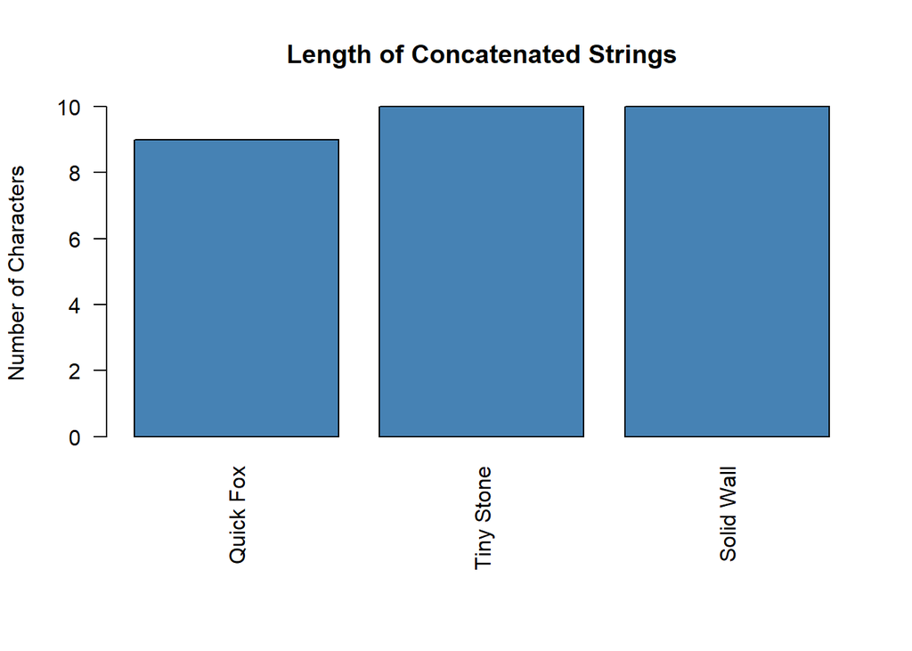

```r
multi <- concat_strings(c("Quick", "Tiny", "Solid"), c("Fox", "Stone", "Wall"))
plot(multi)
```

If only one concatenated string is present, a warning is shown:

```r
single <- concat_strings("One", "Word")
plot(single)
```

```
#> Warning in plot.concat_result(single): Not enough data to create a meaningful
#> plot. Need at least 2 strings.
```

## Conclusion

This package demonstrates how basic string operations can be extended using S3 object-oriented programming in R. It’s ideal for learning how to wrap functionality into reusable and testable code, and for showing how to build a minimal, clean R package with proper testing, documentation, and extensibility.

## License

MIT © 2025

[output not shown]